# patientSim: an ecosystem for process-explicit, patient-level simulation

## What problem is this ecosystem trying to solve?

Electronic health records (EHRs) are not a clean spreadsheet with a tidy baseline and a neat follow-up schedule. They are a **tangled timeline**: labs on irregular days, office visits whenever someone shows up, and clinical events that can pre-empt everything.

If you model EHR data as if it lived on a single clock, you usually end up choosing one of two compromises:

- **Over-discretize** time (fixed cycles, forced regularity), or
- **Over-simplify** processes (one outcome at a time, one “time-to-event” lens)

The *patientSim* ecosystem exists to make a different compromise:

> Be explicit about **multiple event processes** unfolding within a patient, each with its own tempo, and let you view the *same* raw data through multiple **lenses** that match the modeling task.

A second, equally important choice: *patientSim* is **model-first**. You define the key components of your model **before** you look at any specific dataset, so teams can focus on mechanisms and co-evolution over time, rather than isolated relationships among observed indicators.

### A quick contrast

| Orientation | Typical first question | Typical pitfall |
| --- | --- | --- |
| Data-first | “What associations are in this dataset?” | The dataset defines the model, implicitly |
| Model-first (patientSim) | “What processes must exist to generate these data?” | Over-specifying too early; mitigate by iterating from toy → fitted components |

## Multiple event processes, one patient

Here’s a simple mental model we’ll reuse throughout the vignettes.

- **Labs**: irregular and often frequent (a *faster* event process)
- **Office visits**: irregular but less frequent (a *medium* event process)
- **Clinical events**: hospitalizations, MI, stroke, death (a *slower* event process)

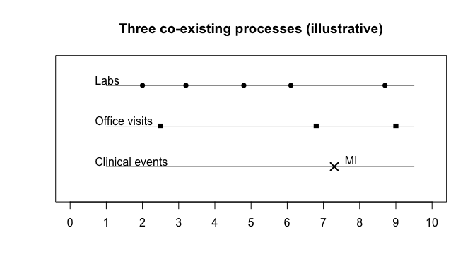

The ecosystem is built around the idea that you should be able to:

1. **Specify** these processes explicitly (what counts as an event, what anchors time)
2. **Prepare** model training/test/validation (**TTV**) tables from raw-ish EHR data under one or more lenses
3. **Simulate** trajectories with transparent state updates and event rules
4. **Summarize** results and **validate forecast accuracy** in different ways without changing the underlying simulated patient histories
5. **Orchestrate** multiple models (for example, a chronic disease model plus a within-hospitalization model) over a single patient time axis

## Ecosystem Components

The ecosystem is modular by design: each package has a narrow job and an explicit contract.

| Component | Job (one sentence) |
| --- | --- |
| patientSimCore | Owns simulation “truth”: timekeeping, patient state, event logs, and the engine that runs a model |
| patientSimPrepare | Transforms raw longitudinal inputs into model training/test/validation (**TTV**) tables (often under multiple lenses) |
| patientSimForecast | Read-only summaries and reporting views of simulated patient histories |
| patientSimValidation | Evaluates simulated vs observed with explicit masks and denominators |
| patientSimOrchestrate | Coordinates scenario runs and comparisons across bundles, or composes multiple bundles over one patient timeline |
| patientSimModelTemplate | A starting point for creating new model packages that follow ecosystem conventions |
| patientSimASCVD | A didactic, worked example that ties the ecosystem together |

## Example Model: Cardiovascular Disease

In this package, we’ll use a model for **atherosclerotic cardiovascular disease (ASCVD)** as a primary teaching example.

In this vignette, we will keep the example **self-contained** and intentionally “toy”: we’ll define the core model components directly in the vignette so you can see their structure.

Later vignettes will show how to replace these toy components with models trained from EHR-derived tables (and how to validate and compare scenarios).

### 1) Schema: what exists in the model world

A schema is the vocabulary of the model: state variables, event types, and basic conventions.

```r
library(patientSimCore)

# Best practice: declare the model time unit up front.
# We do this in a shared "context" object (ctx), which is passed into the Engine
# at run-time. Downstream packages can use ctx$time$unit to label and sanity-check
# time-related quantities.
ctx <- patientSimCore::set_time_unit(ctx = list(), unit = "years")

# patientSimCore schemas are named lists of variable descriptors.
# Each variable has at least:
#   - default: baseline value when init does not provide it
#   - type: used by downstream summary/validation code
# and may also include:
#   - coerce / validate
#   - blocks: panel membership (e.g., BP, lipids)
schema <- list(
  age = list(
    type     = "continuous",
    default  = 50,
    coerce   = as.numeric,
    validate = function(x) length(x) == 1L && (is.na(x) || (is.finite(x) && x >= 0))
  ),

  sbp = list(
    type     = "continuous",
    default  = 120,
    coerce   = as.numeric,
    validate = function(x) length(x) == 1L && (is.na(x) || is.finite(x)),
    blocks   = "bp"
  ),
  dbp = list(
    type     = "continuous",
    default  = 80,
    coerce   = as.numeric,
    validate = function(x) length(x) == 1L && (is.na(x) || is.finite(x)),
    blocks   = "bp"
  ),

  ldl = list(
    type     = "continuous",
    default  = 120,
    coerce   = as.numeric,
    validate = function(x) length(x) == 1L && (is.na(x) || is.finite(x)),
    blocks   = "lipids"
  ),
  hdl = list(
    type     = "continuous",
    default  = 50,
    coerce   = as.numeric,
    validate = function(x) length(x) == 1L && (is.na(x) || is.finite(x)),
    blocks   = "lipids"
  ),

  diabetes = list(
    type     = "binary",
    levels   = c("0","1"),
    default  = FALSE,
    coerce   = as.logical,
    validate = function(x) length(x) == 1L && (is.na(x) || is.logical(x))
  ),
  smoker = list(
    type     = "binary",
    levels   = c("0","1"),
    default  = FALSE,
    coerce   = as.logical,
    validate = function(x) length(x) == 1L && (is.na(x) || is.logical(x))
  )
)

# Optional: let Core check that this looks like a schema.
schema_validate(schema)

# Show the shape, without printing a wall of text.
str(schema, max.level = 1)
```

```
#> List of 7
#>  $ age     :List of 4
#>  $ sbp     :List of 5
#>  $ dbp     :List of 5
#>  $ ldl     :List of 5
#>  $ hdl     :List of 5
#>  $ diabetes:List of 5
#>  $ smoker  :List of 5
```

```r
schema$age
```

```
#> $type
#> [1] "continuous"
#>
#> $default
#> [1] 50
#>
#> $coerce
#> function (x, ...)  .Primitive("as.double")
#>
#> $validate
#> function (x)
#> length(x) == 1L && (is.na(x) || (is.finite(x) && x >= 0))
```

```r
schema$ldl
```

```
#> $type
#> [1] "continuous"
#>
#> $default
#> [1] 120
#>
#> $coerce
#> function (x, ...)  .Primitive("as.double")
#>
#> $validate
#> function (x)
#> length(x) == 1L && (is.na(x) || is.finite(x))
#>
#> $blocks
#> [1] "lipids"
```

### 2) ModelBundle: a portable model artifact

A **ModelBundle** is a single object that contains everything needed to simulate: it proposes candidate next events for one or more processes, applies state updates, and decides when to stop.

patientSimCore expects a bundle with (at minimum):

- `propose_events(patient, ctx, ...)` (multiple processes can propose an event)
- `transition(patient, event, ctx)` (update state given the selected event)
- `stop(patient, event, ctx)` (terminal logic)
- `observe(patient, event, ctx)` *(optional)*: what to record after each event (Core will still maintain the event log either way)
- `refresh_rules(...)` *(optional)*: tells the engine which processes need to re-propose their next event after changes

You’ll see a `ctx` argument threaded through these functions. `ctx` is just a run-level “context” list: it’s how you pass shared settings like the time unit (years vs days) and optional model parameters into the simulation.

We’ll build that list **right here**, one component at a time.

One pragmatic note: `observe()` is optional because Core always maintains an internal event log. If your bundle doesn’t provide `observe()`, you can still simulate, but you won’t get a user-friendly per-event table back.

Before we start, one vocabulary note:

- A **rate** is “how often something happens” (for example, 3 lab draws per year).
- A **hazard** is a rate that can depend on the patient’s current state (for example, MI risk increasing with age and LDL).

In this toy model we use both ideas, but we keep the numbers intentionally tame so the output stays readable.

```r
# We start by defining how frequently each process proposes events.
# Everything below is intentionally toy and tuned only for readable output.

# Helper: exponential waiting time given a rate per year
rexp_dt <- function(rate_per_year) stats::rexp(1, rate = rate_per_year)

# --- (a) Process rates / hazards (toy, NOT clinical) ---
# Labs are a faster measurement process; office visits are a medium process.
rate_labs   <- function(state) 3.0
rate_office <- function(state) 1.0

# Clinical events are modeled as a slower process.
# These hazards are intentionally tiny here so we get readable trajectories.
hazard_mi <- function(state) {
  lin <- -14.8 + 0.03 * (state$age - 50) + 0.010 * (state$sbp - 120) + 0.008 * (state$ldl - 120) +
    0.7 * as.integer(state$diabetes) + 0.6 * as.integer(state$smoker)
  exp(lin)
}
hazard_stroke <- function(state) {
  lin <- -15.1 + 0.03 * (state$age - 50) + 0.012 * (state$sbp - 120) + 0.004 * (state$ldl - 120) +
    0.6 * as.integer(state$diabetes) + 0.4 * as.integer(state$smoker)
  exp(lin)
}
hazard_hosp <- function(state) {
  lin <- -15.0 + 0.02 * (state$age - 50) + 0.006 * (state$sbp - 120) + 0.004 * (state$ldl - 120)
  exp(lin)
}
hazard_death <- function(state) {
  lin <- -15.6 + 0.04 * (state$age - 50) + 0.003 * (state$sbp - 120) + 0.002 * (state$ldl - 120)
  exp(lin)
}
```

Now we define the first required ModelBundle component: **`propose_events()`**.

Think of this as the “calendar clerk” for each process. Each process proposes its next event time, and Core will pick whichever happens first.

One small detail that matters later: each proposal carries a `process_id`. That ID is how Core keeps track of “which process proposed what” (for example, labs vs office visits), which in turn lets you write selective refresh rules and process-specific summaries.

```r
propose_events <- function(patient, ctx = NULL, process_ids = NULL, current_proposals = NULL) {
  t0 <- patient$last_time
  s  <- patient$as_list(c("age","sbp","dbp","ldl","hdl","diabetes","smoker"))

  proposals <- list()

  pid_labs <- "01_labs"
  if (is.null(process_ids) || pid_labs %in% process_ids) {
    proposals[[pid_labs]] <- list(
      process_id = pid_labs,
      time_next  = t0 + rexp_dt(rate_labs(s)),
      event_type = "LAB"
    )
  }

  pid_office <- "02_office"
  if (is.null(process_ids) || pid_office %in% process_ids) {
    proposals[[pid_office]] <- list(
      process_id = pid_office,
      time_next  = t0 + rexp_dt(rate_office(s)),
      event_type = "OFFICE"
    )
  }

  pid_clin <- "03_clinical"
  if (is.null(process_ids) || pid_clin %in% process_ids) {
    t_mi   <- rexp_dt(hazard_mi(s))
    t_st   <- rexp_dt(hazard_stroke(s))
    t_hosp <- rexp_dt(hazard_hosp(s))
    t_dx   <- rexp_dt(hazard_death(s))

    dt <- min(t_mi, t_st, t_hosp, t_dx)
    et <- c("MI","STROKE","HOSP","DEATH")[which.min(c(t_mi, t_st, t_hosp, t_dx))]

    proposals[[pid_clin]] <- list(
      process_id = pid_clin,
      time_next  = t0 + dt,
      event_type = et
    )
  }

  proposals
}
```

Next is **`transition()`**. This is where the model updates state *after* the realized event.

A key point: age updates deterministically with elapsed time, but risk factors only change when an event implies new information (labs update lipids; office visits update blood pressure).

```r
transition <- function(patient, event, ctx = NULL) {
  # Age updates deterministically from the model time unit (years in this vignette).
  dt <- as.numeric(event$time_next - patient$last_time)

  s <- patient$as_list(c("age","sbp","dbp","ldl","hdl","diabetes","smoker"))

  changes <- list(age = s$age + dt)

  # Event-conditional updates. (Toy measurement dynamics, not clinical.)
  if (identical(event$event_type, "LAB")) {
    changes$ldl <- max(30,  s$ldl + stats::rnorm(1, mean = 0, sd = 6))
    changes$hdl <- max(10,  s$hdl + stats::rnorm(1, mean = 0, sd = 3))
  }

  if (identical(event$event_type, "OFFICE")) {
    changes$sbp <- max(60,  s$sbp + stats::rnorm(1, mean = 0, sd = 5))
    changes$dbp <- max(40,  s$dbp + stats::rnorm(1, mean = 0, sd = 3))
  }

  changes
}
```

The engine also needs a **`stop()`** function. Here we stop only on death.

```r
stop <- function(patient, event, ctx = NULL) {
  identical(event$event_type, "DEATH")
}
```

After each event, Core asks the model what it wants to **record**. That’s `observe()`.

```r
observe <- function(patient, event, ctx = NULL) {
  s <- patient$as_list(c("age","sbp","dbp","ldl","hdl","diabetes","smoker"))
  data.frame(
    time       = patient$last_time,
    process_id = event$process_id,
    event_type = event$event_type,
    age        = s$age,
    sbp        = s$sbp,
    dbp        = s$dbp,
    ldl        = s$ldl,
    hdl        = s$hdl,
    diabetes   = s$diabetes,
    smoker     = s$smoker
  )
}
```

Finally, **refresh rules** tell Core which processes should “rethink their next proposal” after an event happens.

In this vignette we keep it simple and refresh everything after every event. Later vignettes show selective refresh rules (for example, simulated time-to-hospitalization doesn’t need to refresh after every lab draw).

```r
refresh_rules <- function(patient, last_event, changes, ctx = NULL) {
  "ALL"
}
```

Now we can assemble the ModelBundle as a plain list.

```r
bundle <- list(
  propose_events = propose_events,
  transition     = transition,
  stop           = stop,
  observe        = observe,
  refresh_rules  = refresh_rules
)

names(bundle)
```

```
#> [1] "propose_events" "transition"     "stop"           "observe"
#> [5] "refresh_rules"
```

### 3) Running the bundle with patientSimCore’s Engine

A quick note on **providers**: Core runs simulations by asking a *provider* for a model bundle.

In `patientSimCore`, a provider is any object with a `$load(model_spec, ...)` method. Core ships with a few provider styles:

- `PackageProvider`: a user-defined in-memory registry (fully supported)
- `FileProvider`: load bundles from R objects on disk (fully supported)
- `MLflowProvider`: a scaffold for MLflow workflows (not yet exercised end-to-end)

Here we use a `PackageProvider`, which is just a named registry that says: “if the engine asks for model **X**, call this builder function to produce its bundle.”

Why a builder function (instead of storing `bundle` directly)? Because in real workflows you often want the provider to:

- inject trained model artifacts into the bundle (loaded from disk, MLflow, etc.)
- swap between fitted versions or scenarios
- construct composite bundles on demand

Now we wire the bundle into Core exactly the way the engine expects: via a provider. This keeps the lesson consistent with the Core vignette scaffold.

```r
# The registry maps a model "name" to a function that can build its ModelBundle.
# Here, the builder simply returns the bundle we already constructed.
prov <- PackageProvider$new(
  registry = list(
    # Minimal builder: ignore args and return the bundle we built above.
    ascvd_toy = function(...) bundle
  )
)

eng <- Engine$new(
  provider   = prov,
  model_spec = list(name = "ascvd_toy"),
  ctx        = ctx
)
```

### 4) Two patients, two trajectories

We’ll simulate two patients with different risk profiles. This is enough to see how the structure works, without drowning in output.

```r
patient_low_risk <- list(
  id = "P1",
  age = 45,
  sbp = 118,
  dbp = 76,
  ldl = 105,
  hdl = 58,
  diabetes = FALSE,
  smoker = FALSE
)

patient_high_risk <- list(
  id = "P2",
  age = 68,
  sbp = 152,
  dbp = 92,
  ldl = 165,
  hdl = 38,
  diabetes = TRUE,
  smoker = TRUE
)

patients <- list(patient_low_risk, patient_high_risk)
```

```r
# Two patients, simulated for 2 years.
# We'll cap max_events so output stays readable even if a rate is high.
max_events <- 200
horizon_years <- 2

# P1
pid1 <- patient_low_risk$id
init1 <- patient_low_risk; init1$id <- NULL
p1 <- patientSimCore::new_patient(init = init1, schema = schema, time0 = 0, event_type0 = "init")
out1 <- eng$run(p1, max_events = max_events, max_time = horizon_years, return_observations = TRUE, ctx = ctx)
traj1 <- out1$observations
traj1$patient_id <- pid1

# P2
pid2 <- patient_high_risk$id
init2 <- patient_high_risk; init2$id <- NULL
p2 <- patientSimCore::new_patient(init = init2, schema = schema, time0 = 0, event_type0 = "init")
out2 <- eng$run(p2, max_events = max_events, max_time = horizon_years, return_observations = TRUE, ctx = ctx)
traj2 <- out2$observations
traj2$patient_id <- pid2

traj1
```

```
#>        time process_id event_type      age      sbp      dbp      ldl      hdl
#> 1 0.2517273    01_labs        LAB 45.25173 118.0000 76.00000 103.2317 57.98270
#> 2 0.3395340    01_labs        LAB 45.33953 118.0000 76.00000 102.9621 57.93413
#> 3 0.5577829    01_labs        LAB 45.55778 118.0000 76.00000 107.6549 58.15782
#> 4 1.7310950  02_office     OFFICE 46.73110 116.8215 74.37134 107.6549 58.15782
#> 5 2.0328360  02_office     OFFICE 47.03284 114.6739 78.08625 107.6549 58.15782
#>   diabetes smoker patient_id
#> 1    FALSE  FALSE         P1
#> 2    FALSE  FALSE         P1
#> 3    FALSE  FALSE         P1
#> 4    FALSE  FALSE         P1
#> 5    FALSE  FALSE         P1
```

```r
traj2
```

```
#>        time process_id event_type      age      sbp      dbp      ldl      hdl
#> 1 0.4177018    01_labs        LAB 68.41770 152.0000 92.00000 160.0077 34.50029
#> 2 0.9286116    01_labs        LAB 68.92861 152.0000 92.00000 157.7475 41.82438
#> 3 1.3436411  02_office     OFFICE 69.34364 145.6819 93.07619 157.7475 41.82438
#> 4 1.6147638    01_labs        LAB 69.61476 145.6819 93.07619 166.5409 42.28414
#> 5 1.7320540    01_labs        LAB 69.73205 145.6819 93.07619 165.8343 39.54794
#> 6 2.4933385    01_labs        LAB 70.49334 145.6819 93.07619 163.2855 38.29100
#>   diabetes smoker patient_id
#> 1     TRUE   TRUE         P2
#> 2     TRUE   TRUE         P2
#> 3     TRUE   TRUE         P2
#> 4     TRUE   TRUE         P2
#> 5     TRUE   TRUE         P2
#> 6     TRUE   TRUE         P2
```

A tiny summary:

```r
summarize_events <- function(traj) {
  as.data.frame(table(traj$event_type), stringsAsFactors = FALSE)
}

list(
  P1_events = summarize_events(traj1),
  P2_events = summarize_events(traj2)
)
```

```
#> $P1_events
#>     Var1 Freq
#> 1    LAB    3
#> 2 OFFICE    2
#>
#> $P2_events
#>     Var1 Freq
#> 1    LAB    5
#> 2 OFFICE    1
```

## What you should take away

At this point, you should have:

- A clear mental model of **multiple event processes** (labs, visits, clinical events)
- A sense of what a **schema** is (the vocabulary)
- A sense of what a **ModelBundle** is (a portable container of components)
- A concrete `transition()` function (the engine that moves a patient forward)

And, importantly, you did *not* need any EHR tables yet.

## Where we go next

From here, the tutorial zooms in:

- **Prepare basics:** how raw longitudinal inputs become model training/test/validation (TTV) tables
- **Lenses:** multiple time partitions for fast/medium/slow processes from the same source data
- **Training:** swap toy components for trained submodels fit from prepared EHR tables
- **Forecasting:** estimate patient-level risk over fixed horizons via repeated simulation runs
- **Validation:** explicit masks/denominators, calibration, and goodness-of-fit
- **Orchestration:** coordinate scenario runs and compose multiple models over one patient timeline